# Heritage Data Writeup (2/2021)

# Subjunctive plots and summaries

**The following figures contain data from the L2 and comparison participants, in order to provide a point of comparison across groups.**

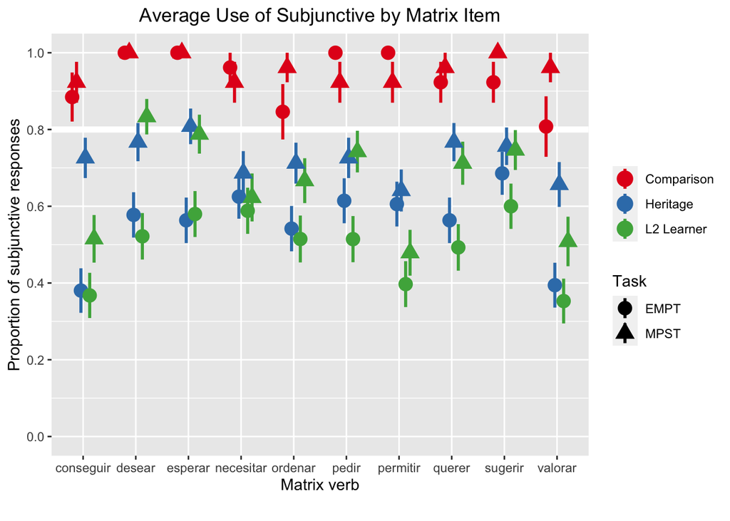

```r
Subjunctive_Aggregate %>%
  ggplot(aes(x = MainVerb, y = Average, color = ExpGroup, shape = Task)) +
  geom_hline(yintercept = 0.8, color = 'white', size = 2) +
  stat_summary(fun.data = mean_se,
               geom = "pointrange", size = 1,
               position = position_dodge(width = 0.5)) +
  scale_color_brewer(palette = "Set1", name = "") +
  scale_y_continuous(breaks = seq (0, 1, 0.2),
                     limits = c(0, 1)) +
  labs(x = "Matrix verb", y = "Proportion of subjunctive responses", caption = "",
       title = "Average Use of Subjunctive by Matrix Item") +
  theme(plot.title = element_text(hjust = 0.5))
```

#### **Figure 1.** Average use of subjunctive morphology by group and task.

## By proficiency level

### Production

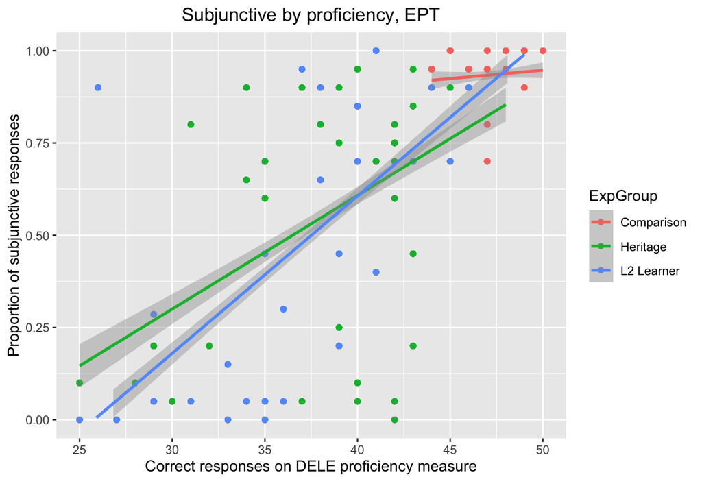

```r
Subjunctive_EPT_Aggregate %>%
  ggplot(aes(x = DELE, y = Part_Avg, color = ExpGroup)) +
  geom_point() +
  geom_smooth(method=lm) +
  xlim(c(25,50)) +
  ylim(c(0,1)) +
  labs(x = 'Correct responses on DELE proficiency measure', y = 'Proportion of subjunctive responses', caption = '',
       title = 'Subjunctive by proficiency, EPT') +
  theme(plot.title = element_text(hjust = 0.5))
```

#### **Figure 2.** Subjunctive use by proficiency level, production task.

### FCT

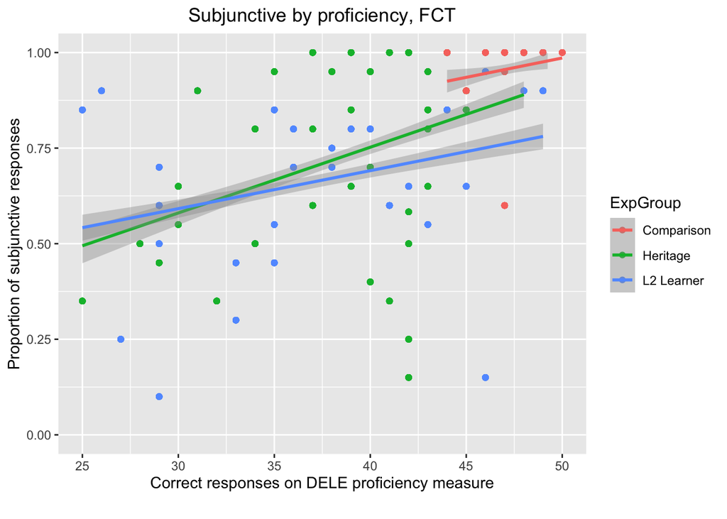

```r
Subjunctive_FCT_Aggregate %>%
  ggplot(aes(x = DELE, y = Part_Avg, color = ExpGroup)) +
  geom_point() +
  geom_smooth(method=lm) +
  xlim(c(25,50)) +
  ylim(c(0,1)) +
  labs(x = 'Correct responses on DELE proficiency measure', y = 'Proportion of subjunctive responses', caption = '',
       title = 'Subjunctive by proficiency, FCT') +
  theme(plot.title = element_text(hjust = 0.5))
```

#### **Figure 3.** Subjunctive preference by proficiency level, FCT.

## By frequency of use

### Production

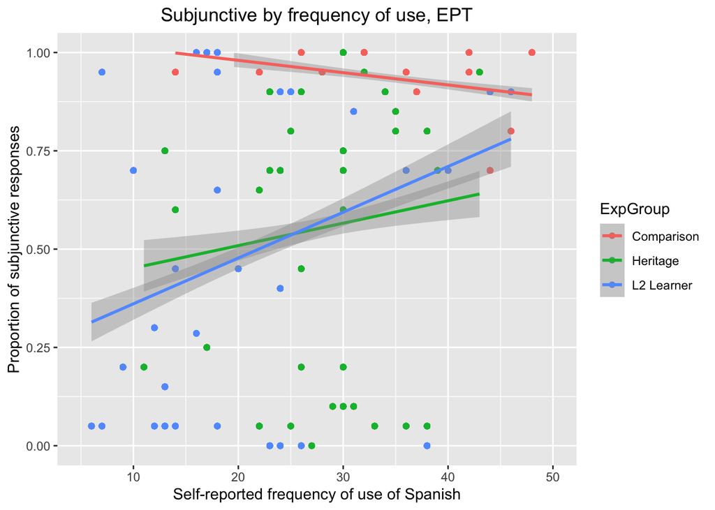

```r
Subjunctive_EPT_Aggregate %>%
  ggplot(aes(x = FofA, y = Part_Avg, color = ExpGroup)) +
  geom_point() +
  geom_smooth(method=lm) +
  xlim(c(5,50)) +
  ylim(c(0,1)) +
  labs(x = 'Self-reported frequency of use of Spanish', y = 'Proportion of subjunctive responses',
       title = 'Subjunctive by frequency of use, EPT') +
  theme(plot.title = element_text(hjust = 0.5))
```

#### **Figure 4.** Subjunctive use by self-reported quantity of use of Spanish, EPT.

### FCT

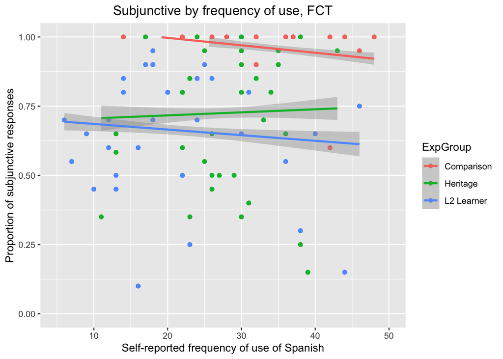

```r
Subjunctive_FCT_Aggregate %>%
  ggplot(aes(x = FofA, y = Part_Avg, color = ExpGroup)) +
  geom_point() +
  geom_smooth(method=lm) +
  xlim(c(5,50)) +
  ylim(c(0,1)) +
  labs(x = 'Self-reported frequency of use of Spanish', y = 'Proportion of subjunctive responses',
       title = 'Subjunctive by frequency of use, FCT') +
  theme(plot.title = element_text(hjust = 0.5))
```

#### **Figure 5.** Subjunctive preference by self-reported quantity of use of Spanish, FCT.

## Age of acquisition

### Production

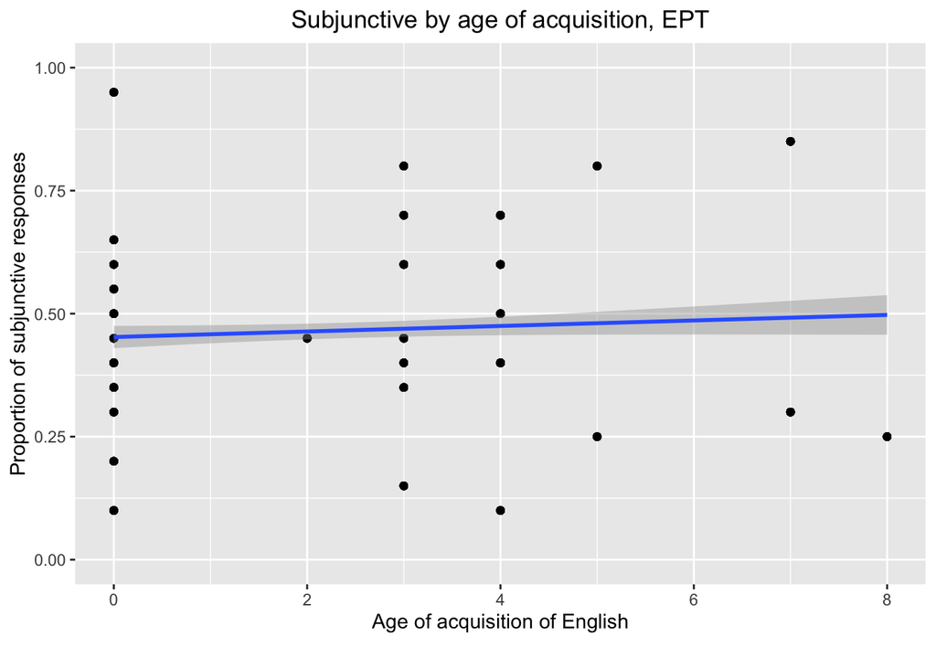

```r
## By age of acquisition
Heritage_EPT_Modified %>%
  ggplot(aes(x = AoA_ENG, y = Part_Avg)) +
  geom_point() +
  geom_smooth(method=lm) +
  xlim(c(0,8)) +
  ylim(c(0,1)) +
  labs(x = 'Age of acquisition of English', y = 'Proportion of subjunctive responses', caption = '',
       title = 'Subjunctive by age of acquisition, EPT') +
  theme(plot.title = element_text(hjust = 0.5))
```

#### **Figure 6.** Subjunctive use by age of acquisition of English, EPT.

### FCT

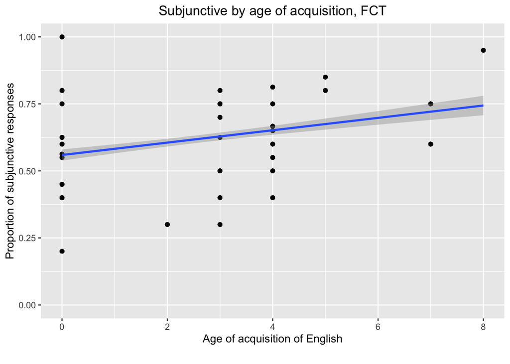

```r
Heritage_FCT_Modified %>%
  ggplot(aes(x = AoA_ENG, y = Part_Avg)) +
  geom_point() +
  geom_smooth(method=lm) +
  xlim(c(0,8)) +
  ylim(c(0,1)) +
  labs(x = 'Age of acquisition of English', y = 'Proportion of subjunctive responses', caption = '',
       title = 'Subjunctive by age of acquisition, FCT') +
  theme(plot.title = element_text(hjust = 0.5))
```

#### **Figure 7.** Subjunctive preference by age of acquisition of English, FCT.

# Preterit plots and summaries

**The following figures contain data from the L2 and comparison participants, in order to provide a point of comparison across groups.**

## By lexical item

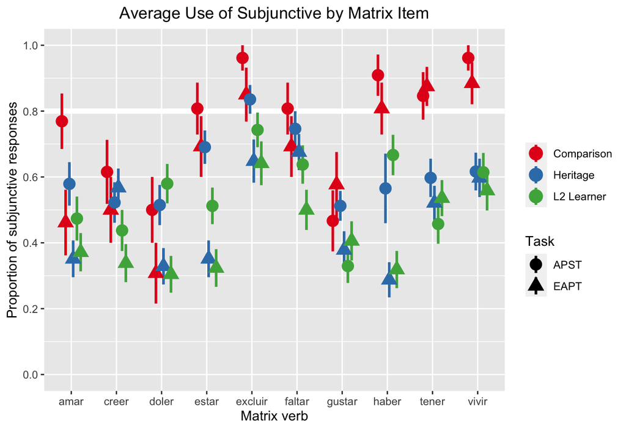

```r
Preterit_Aggregate %>%
  ggplot(aes(x = MainVerb, y = Average, color = ExpGroup, shape = Task)) +
  geom_hline(yintercept = 0.8, color = 'white', size = 2) +
  stat_summary(fun.data = mean_se,
               geom = "pointrange", size = 1,
               position = position_dodge(width = 0.5)) +
  scale_color_brewer(palette = "Set1", name = "") +
  scale_y_continuous(breaks = seq (0, 1, 0.2),
                     limits = c(0, 1)) +
  labs(x = "Matrix verb", y = "Proportion of subjunctive responses", caption = "",
       title = "Average Use of Subjunctive by Matrix Item") +
  theme(plot.title = element_text(hjust = 0.5))
```

## By morphological regularity

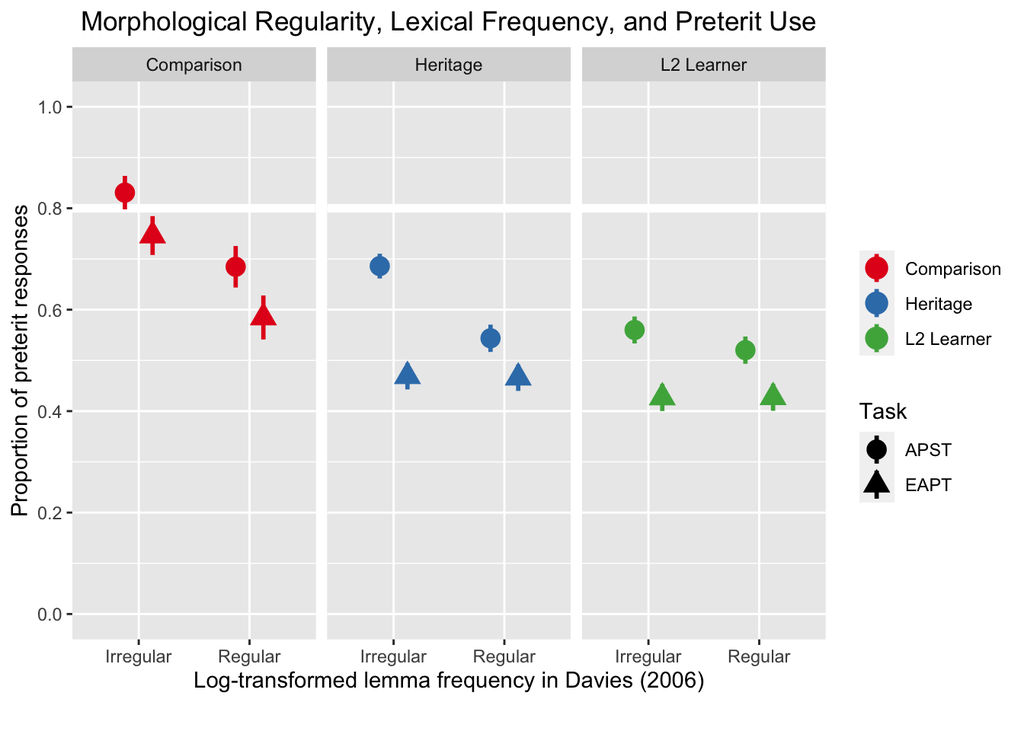

```r
Preterit_Aggregate %>%
  ggplot(aes(x = Reg_Main, y = Average, color = ExpGroup, shape = Task)) +
  facet_grid(cols = vars(ExpGroup)) +
  geom_hline(yintercept = 0.8, color = 'white', size = 2) +
  stat_summary(fun.data = mean_se,
               geom = 'pointrange', size = 1,
               position = position_dodge(width = 0.5)) +
  scale_color_brewer(palette = "Set1", name = "") +
  scale_y_continuous(breaks = seq (0, 1, 0.2),
                     limits = c(0, 1)) +
  labs(x = 'Log-transformed lemma frequency in Davies (2006)', y = 'Proportion of preterit responses', caption = '',
       title = 'Morphological Regularity, Lexical Frequency, and Preterit Use') +
  theme(plot.title = element_text(hjust = 0.5))
```